# Portfolio_Task_2

John Lavack 20001249

2026-03-05

# Exploratory data analysis

There appears to be some difference between the batch scores within the interquartile ranges of the boxes on the box plot. However, there is some over lap, especially when considering outliers in batches 1 and 2. And it is difficult to say for certain as each batch is a sample of 5. Making each part of the box plot one score. At first glance it appears there may be some batch differences worth exploring.

```r
data %>% group_by(Batch) %>% summarise(n = n())
```

```
## # A tibble: 4 × 2
##   Batch     n
##   <fct> <int>
## 1 1         5
## 2 2         5
## 3 3         5
## 4 4         5
```

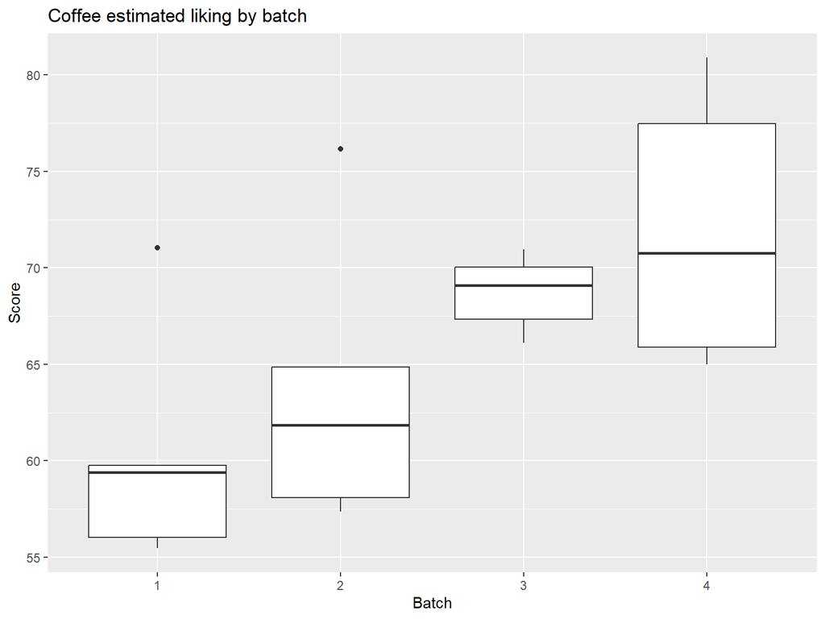

```r
data %>% ggplot(aes(x=Batch, y = Score)) + geom_boxplot() +
  labs(title = 'Coffee estimated liking by batch')
```

# Fitting models

## Linear model

```r
coffee_lm <- lm(Score ~ Batch, data = data)
summary(coffee_lm)
```

```
##
## Call:
## lm(formula = Score ~ Batch, data = data)
##
## Residuals:
##    Min     1Q Median     3Q    Max
## -7.006 -4.444 -1.090  1.570 12.502
##
## Coefficients:
##             Estimate Std. Error t value Pr(>|t|)
## (Intercept)   60.344      2.744  21.991 2.21e-13 ***
## Batch2         3.324      3.881   0.857  0.40435
## Batch3         8.366      3.881   2.156  0.04667 *
## Batch4        11.662      3.881   3.005  0.00839 **
## ---
## Signif. codes:  0 '***' 0.001 '**' 0.01 '*' 0.05 '.' 0.1 ' ' 1
##
## Residual standard error: 6.136 on 16 degrees of freedom
## Multiple R-squared:  0.4012, Adjusted R-squared:  0.2889
## F-statistic: 3.573 on 3 and 16 DF,  p-value: 0.03768
```

```r
#basic anova
anova(coffee_lm)
```

```
## Analysis of Variance Table
##
## Response: Score
##           Df Sum Sq Mean Sq F value  Pr(>F)
## Batch      3 403.56  134.52  3.5729 0.03768 *
## Residuals 16 602.40   37.65
## ---
## Signif. codes:  0 '***' 0.001 '**' 0.01 '*' 0.05 '.' 0.1 ' ' 1
```

```r
#log transform
anova(lm(log(Score) ~ Batch, data = data))
```

```
## Analysis of Variance Table
##
## Response: log(Score)
##           Df   Sum Sq  Mean Sq F value  Pr(>F)
## Batch      3 0.094929 0.031643  3.8139 0.03089 *
## Residuals 16 0.132746 0.008297
## ---
## Signif. codes:  0 '***' 0.001 '**' 0.01 '*' 0.05 '.' 0.1 ' ' 1
```

## Non-parametric model

As the data is small in batch sample size, not really normally distributed, with outliers that can’t be removed (because they are sizable portions of the sample size in their batches) and the response variable is ordinal (a ‘liking’ score), a non-parametric test is worthwhile performing. A GAM model (general additive model which fits here because the batch variable is categorical) shows that batch is weakly significant. In this model the s(Batch, bs = “re’) term treats the batch as a random effect. It assumes batches were randomised. While method = ‘REML’ results in better model estimation of variance components.

```r
coffee_gam <- gam(Score ~ s(Batch, bs = "re"), data = data, method = 'REML')

summary(coffee_gam)
```

```
##
## Family: gaussian
## Link function: identity
##
## Formula:
## Score ~ s(Batch, bs = "re")
##
## Parametric coefficients:
##             Estimate Std. Error t value Pr(>|t|)
## (Intercept)   66.182      2.593   25.52 6.74e-15 ***
## ---
## Signif. codes:  0 '***' 0.001 '**' 0.01 '*' 0.05 '.' 0.1 ' ' 1
##
## Approximate significance of smooth terms:
##           edf Ref.df     F p-value
## s(Batch) 2.16      3 2.573  0.0361 *
## ---
## Signif. codes:  0 '***' 0.001 '**' 0.01 '*' 0.05 '.' 0.1 ' ' 1
##
## R-sq.(adj) =  0.289   Deviance explained =   37%
## -REML = 64.837  Scale est. = 37.65     n = 20
```

Checking this with a Kruskal-Wallis test shows no significant difference between groups. Chi-squared value of 6.98 and P-value of 0.07. Fail to reject the null hypothesis.

```r
#non-parametric test
kruskal.test(Score~Batch,data=data)
```

```
##
##  Kruskal-Wallis rank sum test
##
## data:  Score by Batch
## Kruskal-Wallis chi-squared = 6.9771, df = 3, p-value = 0.07263
```

As the Kruskal-Wallis test showed no difference between groups, a post hoc Dunn test confirms there is no significant difference between any batches.

```r
print(data %>% dunn_test(Score ~ Batch, p.adjust.method = "bonferroni"))
```

```
## # A tibble: 6 × 9
##   .y.   group1 group2    n1    n2 statistic      p p.adj p.adj.signif
## * <chr> <chr>  <chr>  <int> <int>     <dbl>  <dbl> <dbl> <chr>
## 1 Score 1      2          5     5     0.481 0.630  1     ns
## 2 Score 1      3          5     5     1.87  0.0614 0.368 ns
## 3 Score 1      4          5     5     2.24  0.0248 0.149 ns
## 4 Score 2      3          5     5     1.39  0.165  0.988 ns
## 5 Score 2      4          5     5     1.76  0.0777 0.466 ns
## 6 Score 3      4          5     5     0.374 0.708  1     ns
```

# Residual Analysis

## Linear residuals

There is clear uneven variance between the residuals and the batches. Some have much larger variance than other batches. Batch 3 for example has far less variance, while batches 1, 2 and 4 have wide, but not even variance between groups. Indicating perhaps a confounding variable(s) at play. The residuals and fitted plot indicate a non-linear trend as there is a clear patern within and between groups. The residuals are not normally distributed, as the Q-Q plot show clear deviation from normality.  
The scale location plot confirms the lack of homoscedasticity with an uneven trend line. The constant leverage plot indicates that the residuals are not evenly distributed across factor levels, but lack a clear trend. It would appear that batches 1 and 2 are more similar to each other, as are batches 3 and 4. These two pairs are not similar to each other. An autocorrelation plot show only one spike beyond confidence bands, indicating no serious auto-correlation. Which is confirmed by a L Jung test with lag of 2 which fails to reject the null hypothesis of no auto-correcaltion (P-valu 0.32).

Residuals are not normal: Normality assumption failed. Residuals are independent: Independence assumption passed. Residuals are heteroskedastic: Homoscedasticity assumption failed. Residuals are not linear: Linearity assumption failed.

Therefore, the conclusions drawn from this model are misleading.

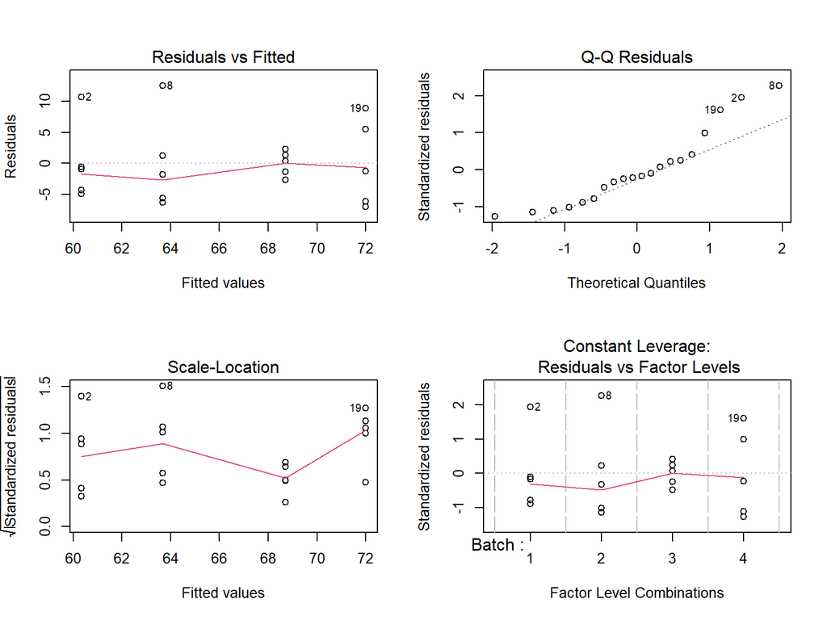

```r
par(mfrow = c(2, 2))
plot(coffee_lm)
```

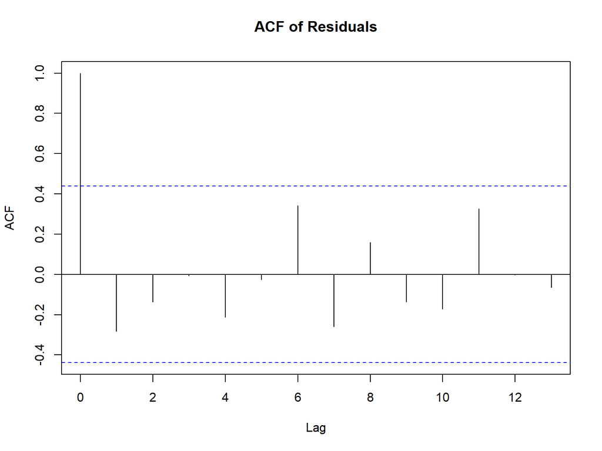

```r
acf(coffee_lm$residuals, main = "ACF of Residuals")
```

```r
Box.test(residuals(coffee_lm), type = "Ljung-Box", lag = 2)
```

```
##
##  Box-Ljung test
##
## data:  residuals(coffee_lm)
## X-squared = 2.303, df = 2, p-value = 0.3162
```

### Tukey analysis

```r
coffee_tukey <- glht(coffee_lm, linfct = mcp(Batch = "Tukey"))
coffee_tukey
```

```
##
##   General Linear Hypotheses
##
## Multiple Comparisons of Means: Tukey Contrasts
##
##
## Linear Hypotheses:
##            Estimate
## 2 - 1 == 0    3.324
## 3 - 1 == 0    8.366
## 4 - 1 == 0   11.662
## 3 - 2 == 0    5.042
## 4 - 2 == 0    8.338
## 4 - 3 == 0    3.296
```

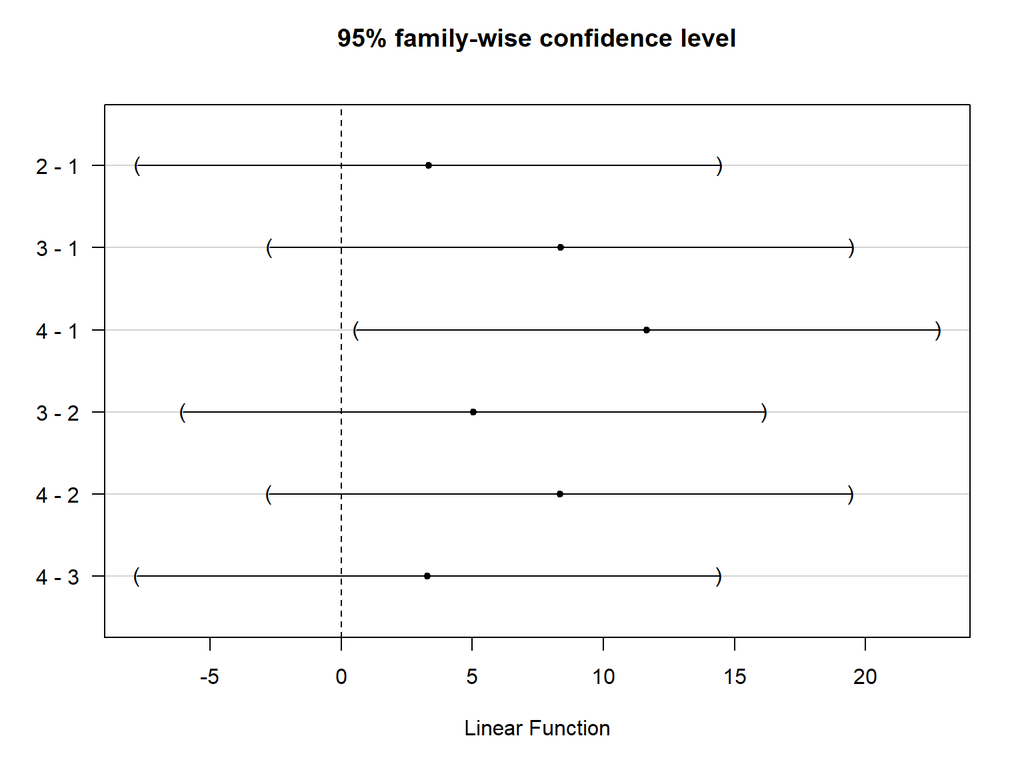

```r
plot(coffee_tukey)
```

## GAM residuals

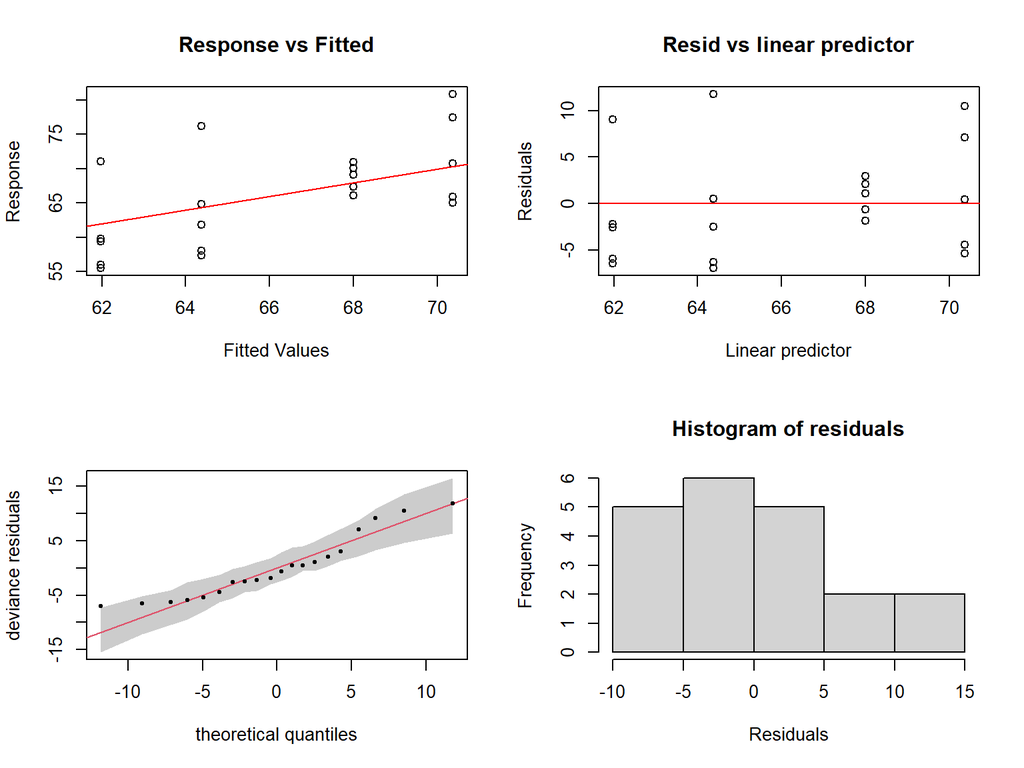

```r
op <- par(mfrow = c(2, 2))
plot(fitted(coffee_gam), data$Score, xlab = "Fitted Values", ylab = "Response", main = "Response vs Fitted")
abline(a=0, b = 1, col = "red")

# op2 <- par(mfrow = c(1, 2))
plot(fitted(coffee_gam), coffee_gam$residuals, xlab = "Linear predictor", ylab = "Residuals", main = "Resid vs linear predictor")
abline(h=0, col = "red")

qq.gam(coffee_gam, rep = 100, level = 0.9, pch = 19, cex = 0.5)

hist(coffee_gam$residuals, xlab="Residuals", main = 'Histogram of residuals')
```

```r
par(op)
```

### Visualising results of non-paramteric test

[figure not shown]

```r
data$ranks <- rank(data$Score)

# Compute residuals (rank - group median rank)
group_medians <- tapply(data$ranks, data$Score, median)
data$residuals <- data$ranks - group_medians[data$Batch]

# Plot residuals
ggplot(data, aes(x = Batch, y = residuals)) +
  geom_boxplot() +
  labs(title = "Residuals (Ranks - Batch Median Ranks)", y = "Residuals")
```

# Statistical conclusion

# Real world advice

These data were too few to get a decent analysis. There is perhaps a confounding variable or perhaps not enough experimental units to observe any trends through the random noise. Re-run this experiment with more experimental units per batch. Keep the four batches and the randomisation in the experiment, but run the experiment longer. Aim for 20 experimental units per batch as a minimum. Additionally, capture more data about the person being measured. At least their age and sex. And keep data about the setting of the measurements taken. Such as time of day and internal and external temperatures for starters. Perhaps these can help guide the analysis and isolate/identify the unknown confounding variable.

However, if you are happy with these results, then you can take it on faith that there is no difference between the groups and can proceed with the process which creates the most coffee at the lowest cost to you.